# Wrangling a Dataset

```python
#import pandas, numpy, requests, beautifulsoup ,
import pandas as pd
import numpy as np
import requests
from bs4 import BeautifulSoup
import json
```

```python
#import tweepy
import tweepy
```

## First dataset

> WeRateDogs Twitter archive data (twitter_archive_enhanced.csv)

```python
#upload the csv dataset, twitter-archive-enhanced csv file
twitter_df= pd.read_csv('twitter-archive-enhanced.csv')
twitter_df.head(1)
twitter_df.shape
```

```
(2356, 17)
```

## Second dataset

> tweet image prediction (image_predictions.tsv)

```python
#use the url to programmatically download the image-prediction tsv file
image_prediction= 'https://d17h27t6h515a5.cloudfront.net/topher/2017/August/599fd2ad_image-predictions/image-predictions.tsv'
#use the request to get the url
tweet_image= requests.get(image_prediction)
```

```python
#the request was successful
tweet_image
```

```
<Response [200]>
```

## Third Dataset

> additional data via the Twitter API (tweet_json.txt)

```python
consumer_key = ''
consumer_secret = ''
access_token = ''
access_secret = ''

auth = tweepy.OAuthHandler(consumer_key, consumer_secret)
auth.set_access_token(access_token, access_secret)

api = tweepy.API(auth)
```

```python
#make a list of all ids in the Weratedogs csv file to loop through
my_tweets_id_list = twitter_df['tweet_id'].tolist()
```

```python
#check that the list has been created. Print the first three tweet_id
print(my_tweets_id_list[0:3])
```

```
[892420643555336193, 892177421306343426, 891815181378084864]
```

> Loop through the list and query the likes and retweets for each tweet id

> > Saved the results in a list for csv and dictionary for json

> > > View the saved json file and the csv file

```python
loop through the whole list, the initial dataframe with twitter id has 2356 rows
test_list=my_tweets_id_list[0:2357]
 #we create the following structures to hold the tweets, for formating purposes we create a json one and a csv one, this can be merged into one to save on the
# processing speed / space especially for bigger inputs, but for this exercise we can go along with the dirty but faster method of creating 2 lists
saved_json_tweets = [];
saved_csv_tweets = [["id","likes","retweets"]];

# we add a way for ignoring errors, the better approach is to catch the specific error
for id in test_list:
    try:
        tweet_status = api.get_status(id, tweet_mode='extended')
        tweet_status_json = tweet_status._json
        retweets_count = tweet_status_json["retweet_count"]
        favorite_count = tweet_status_json["favorite_count"]
        saved_json_tweets.append({"id":id, "likes":favorite_count, "retweets":retweets_count})
        saved_csv_tweets.append([id,favorite_count,retweets_count])
    except:
        pass
```

```python
with open('my_tweet_file','w') as my_file_handle:
    json.dump(saved_json_tweets,my_file_handle)

import csv
with open('my_csv_tweet_file.csv', 'w', newline='') as file:
    writer = csv.writer(file)
    writer.writerows(saved_csv_tweets)
```

```python
f = open('my_tweet_file')

#returns JSON object as
#a dictionary
data = json.load(f)
data
```

*Open the Datasets*

```python
tweets_df= pd.read_csv('my_csv_tweet_file.csv')
predictions_df= pd.read_csv('image-predictions.tsv',sep='\t')
predictions_df.head(2)
```

|  | tweet_id | jpg_url | img_num | p1 | p1_conf | p1_dog | p2 | p2_conf | p2_dog | p3 | p3_conf | p3_dog |
| --- | --- | --- | --- | --- | --- | --- | --- | --- | --- | --- | --- | --- |
| 0 | 666020888022790149 | https://pbs.twimg.com/media/CT4udn0WwAA0aMy.jpg | 1 | Welsh_springer_spaniel | 0.465074 | True | collie | 0.156665 | True | Shetland_sheepdog | 0.061428 | True |
| 1 | 666029285002620928 | https://pbs.twimg.com/media/CT42GRgUYAA5iDo.jpg | 1 | redbone | 0.506826 | True | miniature_pinscher | 0.074192 | True | Rhodesian_ridgeback | 0.072010 | True |

```python
tweets_df.head(2)
```

|  | id | likes | retweets |
| --- | --- | --- | --- |
| 0 | 892420643555336193 | 33839 | 7018 |
| 1 | 892177421306343426 | 29355 | 5303 |

## ASSESSING THE DATASETS

```python
tweets_df.shape
```

```
(1294, 3)
```

```python
tweets_df.describe()
```

|  | id | likes | retweets |
| --- | --- | --- | --- |
| count | 1.294000e+03 | 1294.000000 | 1294.000000 |
| mean | 7.374488e+17 | 7458.484544 | 2270.337713 |
| std | 7.289044e+16 | 11721.855497 | 4121.010451 |
| min | 6.660209e+17 | 0.000000 | 1.000000 |
| 25% | 6.841291e+17 | 1866.000000 | 530.500000 |
| 50% | 7.065655e+17 | 3017.000000 | 998.000000 |
| 75% | 7.485134e+17 | 7446.500000 | 2579.250000 |
| max | 8.924206e+17 | 145013.000000 | 70826.000000 |

```python
tweets_df.info()
```

```
<class 'pandas.core.frame.DataFrame'>
RangeIndex: 1294 entries, 0 to 1293
Data columns (total 3 columns):
 #   Column    Non-Null Count  Dtype
---  ------    --------------  -----
 0   id        1294 non-null   int64
 1   likes     1294 non-null   int64
 2   retweets  1294 non-null   int64
dtypes: int64(3)
memory usage: 30.5 KB
```

```python
tweets_df.isnull().sum()
```

```
id          0
likes       0
retweets    0
dtype: int64
```

```python
tweets_df.duplicated().sum()
```

```
0
```

```python
print(predictions_df.shape)
predictions_df.info()
```

```
(2075, 12)
<class 'pandas.core.frame.DataFrame'>
RangeIndex: 2075 entries, 0 to 2074
Data columns (total 12 columns):
 #   Column    Non-Null Count  Dtype
---  ------    --------------  -----
 0   tweet_id  2075 non-null   int64
 1   jpg_url   2075 non-null   object
 2   img_num   2075 non-null   int64
 3   p1        2075 non-null   object
 4   p1_conf   2075 non-null   float64
 5   p1_dog    2075 non-null   bool
 6   p2        2075 non-null   object
 7   p2_conf   2075 non-null   float64
 8   p2_dog    2075 non-null   bool
 9   p3        2075 non-null   object
 10  p3_conf   2075 non-null   float64
 11  p3_dog    2075 non-null   bool
dtypes: bool(3), float64(3), int64(2), object(4)
memory usage: 152.1+ KB
```

```python
predictions_df.duplicated().sum()
```

```
0
```

```python
predictions_df.describe()
```

|  | tweet_id | img_num | p1_conf | p2_conf | p3_conf |
| --- | --- | --- | --- | --- | --- |
| count | 2.075000e+03 | 2075.000000 | 2075.000000 | 2.075000e+03 | 2.075000e+03 |
| mean | 7.384514e+17 | 1.203855 | 0.594548 | 1.345886e-01 | 6.032417e-02 |
| std | 6.785203e+16 | 0.561875 | 0.271174 | 1.006657e-01 | 5.090593e-02 |
| min | 6.660209e+17 | 1.000000 | 0.044333 | 1.011300e-08 | 1.740170e-10 |
| 25% | 6.764835e+17 | 1.000000 | 0.364412 | 5.388625e-02 | 1.622240e-02 |
| 50% | 7.119988e+17 | 1.000000 | 0.588230 | 1.181810e-01 | 4.944380e-02 |
| 75% | 7.932034e+17 | 1.000000 | 0.843855 | 1.955655e-01 | 9.180755e-02 |
| max | 8.924206e+17 | 4.000000 | 1.000000 | 4.880140e-01 | 2.734190e-01 |

```python
#min value in the p1_conf column
min_pF= predictions_df['p1_conf'].min()
print(min_pF)
#min value in the p2_conf column
min_pS= predictions_df['p2_conf'].min()
print(min_pS)
#min value in the p3_conf column
min_pT= predictions_df['p3_conf'].min()
print(min_pT)
```

```
0.0443334
1.0113000000000001e-08
1.7401699999999998e-10
```

```python
#max value in the p1_conf column
max_pF= predictions_df['p1_conf'].max()
print(max_pF)
#max value in the p2_conf column
max_pS= predictions_df['p2_conf'].max()
print(max_pS)
#max value in the p3_conf column
max_pT= predictions_df['p3_conf'].max()
print(max_pT)
```

```
1.0
0.488014
0.273419
```

#### The values in the three columns should be between 1 and 0.

```python
twitter_df.describe()
```

|  | tweet_id | in_reply_to_status_id | in_reply_to_user_id | retweeted_status_id | retweeted_status_user_id | rating_numerator | rating_denominator |
| --- | --- | --- | --- | --- | --- | --- | --- |
| count | 2.356000e+03 | 7.800000e+01 | 7.800000e+01 | 1.810000e+02 | 1.810000e+02 | 2356.000000 | 2356.000000 |
| mean | 7.427716e+17 | 7.455079e+17 | 2.014171e+16 | 7.720400e+17 | 1.241698e+16 | 13.126486 | 10.455433 |
| std | 6.856705e+16 | 7.582492e+16 | 1.252797e+17 | 6.236928e+16 | 9.599254e+16 | 45.876648 | 6.745237 |
| min | 6.660209e+17 | 6.658147e+17 | 1.185634e+07 | 6.661041e+17 | 7.832140e+05 | 0.000000 | 0.000000 |
| 25% | 6.783989e+17 | 6.757419e+17 | 3.086374e+08 | 7.186315e+17 | 4.196984e+09 | 10.000000 | 10.000000 |
| 50% | 7.196279e+17 | 7.038708e+17 | 4.196984e+09 | 7.804657e+17 | 4.196984e+09 | 11.000000 | 10.000000 |
| 75% | 7.993373e+17 | 8.257804e+17 | 4.196984e+09 | 8.203146e+17 | 4.196984e+09 | 12.000000 | 10.000000 |
| max | 8.924206e+17 | 8.862664e+17 | 8.405479e+17 | 8.874740e+17 | 7.874618e+17 | 1776.000000 | 170.000000 |

```python
#count the number of values in the rating_numerator column that exceed the limit(20)
limit= 20
count_numerator= (twitter_df['rating_numerator'] > limit).sum()
print(count_numerator)
```

```
24
```

```python
#count the number of values in the rating_denominator column that exceed the limit(10)
limit= 10
count_denominator= (twitter_df['rating_denominator'] > limit).sum()
print(count_denominator)
```

```
20
```

```python
twitter_df.info()
```

```
<class 'pandas.core.frame.DataFrame'>
RangeIndex: 2356 entries, 0 to 2355
Data columns (total 17 columns):
 #   Column                      Non-Null Count  Dtype
---  ------                      --------------  -----
 0   tweet_id                    2356 non-null   int64
 1   in_reply_to_status_id       78 non-null     float64
 2   in_reply_to_user_id         78 non-null     float64
 3   timestamp                   2356 non-null   object
 4   source                      2356 non-null   object
 5   text                        2356 non-null   object
 6   retweeted_status_id         181 non-null    float64
 7   retweeted_status_user_id    181 non-null    float64
 8   retweeted_status_timestamp  181 non-null    object
 9   expanded_urls               2297 non-null   object
 10  rating_numerator            2356 non-null   int64
 11  rating_denominator          2356 non-null   int64
 12  name                        2356 non-null   object
 13  doggo                       2356 non-null   object
 14  floofer                     2356 non-null   object
 15  pupper                      2356 non-null   object
 16  puppo                       2356 non-null   object
dtypes: float64(4), int64(3), object(10)
memory usage: 313.0+ KB
```

```python
#the duplicated entries and null
print('duplicated:' ,twitter_df.duplicated().sum())
twitter_df.isnull().sum()
```

```
duplicated: 0
```

```
tweet_id                         0
in_reply_to_status_id         2278
in_reply_to_user_id           2278
timestamp                        0
source                           0
text                             0
retweeted_status_id           2175
retweeted_status_user_id      2175
retweeted_status_timestamp    2175
expanded_urls                   59
rating_numerator                 0
rating_denominator               0
name                             0
doggo                            0
floofer                          0
pupper                           0
puppo                            0
dtype: int64
```

```python
# after visual assessment, the name column has entries with name as None, the names can however be seen in the tweet, for instance
#row number 351, the name is blue while the name is None

#the number of names as None
twitter_df['name'].value_counts()
```

```
None          745
a              55
Charlie        12
Cooper         11
Lucy           11
             ...
Dex             1
Ace             1
Tayzie          1
Grizzie         1
Christoper      1
Name: name, Length: 957, dtype: int64
```

```python
twitter_df.isnull().sum()
```

```
tweet_id                         0
in_reply_to_status_id         2278
in_reply_to_user_id           2278
timestamp                        0
source                           0
text                             0
retweeted_status_id           2175
retweeted_status_user_id      2175
retweeted_status_timestamp    2175
expanded_urls                   59
rating_numerator                 0
rating_denominator               0
name                             0
doggo                            0
floofer                          0
pupper                           0
puppo                            0
dtype: int64
```

> QUALITY ISSUES

1 incomplete data( missing values in some columns)

2 timestamp is in a string format

3 The tweet_id as an integer , instead of string

4 Twitter_df rating_numerator has values extreemly high , such as 1776, 960 aand many more. the denominator column has the max value as 170, the standard denominator is 10.

5.the predictions file should have more descriptive columns

6 Names in the predictions flat file have an _ as a delimiter.

7 Twitter_df , 'name' column with 745 entries as None, while in the tweet the names are indicated.

8 Lower case names in predictions flat file

> TIDINESS ISSUES
1. The dog types names are split into four columns instead of having one column 'dog type' and having doggo,floofer, pupper and puppo as value
2. the tweet_file containing likes and retweets ,and the image predictions have similar observation unit as the twitter archve dataset, but there are three tables. > the tables however have different number of rows.

# Clean

## Code

```python
#Make copies of the datasets
twitter_clean = twitter_df.copy()
predictions_clean = predictions_df.copy()
tweets_clean = tweets_df.copy()
```

```python
#Missing Data from these columns cant be cleaned so we drop the columns
twitter_clean = twitter_clean.drop(labels=['in_reply_to_status_id','in_reply_to_user_id','expanded_urls','retweeted_status_id','retweeted_status_user_id','retweeted_status_timestamp'], axis=1)
```

### Test

```python
print(list(twitter_clean))
twitter_clean.isnull().sum()
```

```
['tweet_id', 'timestamp', 'source', 'text', 'rating_numerator', 'rating_denominator', 'name', 'doggo', 'floofer', 'pupper', 'puppo']
```

```
tweet_id              0
timestamp             0
source                0
text                  0
rating_numerator      0
rating_denominator    0
name                  0
doggo                 0
floofer               0
pupper                0
puppo                 0
dtype: int64
```

## Define

### Timestamp is in a string format

> The timestamp column is in a string format and needs to be in a date-time format Action is to change the column data type

### Code

```python
#Change the data type to datetime
twitter_clean['timestamp'] = pd.to_datetime(twitter_clean['timestamp'])
```

### Test

```python
twitter_clean.dtypes
```

```
tweet_id                            int64
timestamp             datetime64[ns, UTC]
source                             object
text                               object
rating_numerator                    int64
rating_denominator                  int64
name                               object
doggo                              object
floofer                            object
pupper                             object
puppo                              object
dtype: object
```

### Define

#### Twitter_df rating_numerator has values extreemly high , such as 1776, 960 aand many more. the denominator column has the max value as 170, the standard denominator is 10.

##### Change the denominator values to 10

#### Change the numerator values above 20 with the mean

```python
#get the mean
twitter_clean.describe()
```

|  | tweet_id | rating_numerator | rating_denominator |
| --- | --- | --- | --- |
| count | 2.356000e+03 | 2356.000000 | 2356.000000 |
| mean | 7.427716e+17 | 13.126486 | 10.455433 |
| std | 6.856705e+16 | 45.876648 | 6.745237 |
| min | 6.660209e+17 | 0.000000 | 0.000000 |
| 25% | 6.783989e+17 | 10.000000 | 10.000000 |
| 50% | 7.196279e+17 | 11.000000 | 10.000000 |
| 75% | 7.993373e+17 | 12.000000 | 10.000000 |
| max | 8.924206e+17 | 1776.000000 | 170.000000 |

```python
#View the other values besides 10
twitter_clean['rating_denominator'].value_counts()
```

```
10     2333
11        3
50        3
20        2
80        2
70        1
7         1
15        1
150       1
170       1
0         1
90        1
40        1
130       1
110       1
16        1
120       1
2         1
Name: rating_denominator, dtype: int64
```

```python
#replace values that arent 10 to 10, the standard denominator
list_dm= twitter_clean['rating_denominator'].to_list()
#test purpose
print(list_dm[0:10])
denominator_list= []
for y in list_dm:
    if y !=10:
        y=10
        denominator_list.append(y)
    else:
        denominator_list.append(y)
twitter_clean['rating_denominator']= denominator_list
print(denominator_list[0:10])
```

```
[10, 10, 10, 10, 10, 10, 10, 10, 10, 10]
[10, 10, 10, 10, 10, 10, 10, 10, 10, 10]
```

```python
# View values above 20
limit= 20
count_numerator= (twitter_df['rating_numerator'] > limit).sum()
print(count_numerator)
```

```
24
```

```python
#replace the 24 values with mean= 13
list_df=twitter_clean['rating_numerator'].to_list()
#test purpose
print(list_df[0:10])
twitter_list=[]
for i in list_df:
    if i>20:
        i=13
        twitter_list.append(i)
    else:
        twitter_list.append(i)

print(twitter_list[0:12])
count=0
for x in twitter_list:
    if x < 20:
        count +=1
    else:
        count=count
print(count)
```

```
[13, 13, 12, 13, 12, 13, 13, 13, 13, 14]
[13, 13, 12, 13, 12, 13, 13, 13, 13, 14, 13, 13]
2355
```

```python
twitter_clean['rating_numerator']= twitter_list
```

## Test

```python
limit= 20
count_numerator= (twitter_clean['rating_numerator'] > limit).sum()
print(count_numerator)
```

```
0
```

```python
twitter_clean['rating_denominator'].nunique()
```

```
1
```

# Define

# Code

```python
#change the tweet_id data_type to string
twitter_clean = twitter_clean.astype({"tweet_id": str})
predictions_clean = predictions_clean.astype({"tweet_id": str})
tweets_clean= tweets_clean.astype({'tweet_id': str})
```

# Test

```python
twitter_clean.dtypes
```

```
tweet_id                           object
timestamp             datetime64[ns, UTC]
source                             object
text                               object
rating_numerator                    int64
rating_denominator                  int64
name                               object
doggo                              object
floofer                            object
pupper                             object
puppo                              object
dtype: object
```

```python
predictions_clean.dtypes
```

```
tweet_id     object
jpg_url      object
img_num       int64
p1           object
p1_conf     float64
p1_dog         bool
p2           object
p2_conf     float64
p2_dog         bool
p3           object
p3_conf     float64
p3_dog         bool
dtype: object
```

```python
tweets_clean.dtypes
```

[output not shown]

# Define : Name that have an - delimiter

## Remove the deimiters and have the full names

# Code

```python
predictions_clean['p1']= predictions_clean['p1'].str.replace('_',' ')
predictions_clean['p2']= predictions_clean['p2'].str.replace('_',' ')
predictions_clean['p3']= predictions_clean['p3'].str.replace('_',' ')
```

# Test

```python
predictions_clean.sample(10)
```

|  | tweet_id | jpg_url | img_num | p1 | p1_conf | p1_dog | p2 | p2_conf | p2_dog | p3 | p3_conf | p3_dog |
| --- | --- | --- | --- | --- | --- | --- | --- | --- | --- | --- | --- | --- |
| 1961 | 866450705531457537 | https://pbs.twimg.com/media/DAZAUfBXcAAG_Nn.jpg | 2 | French Bulldog | 0.905334 | True | Boston Bull | 0.078060 | True | Pug | 0.001771 | True |
| 1832 | 836677758902222849 | https://pbs.twimg.com/media/C5x57-TWUAEawQh.jpg | 2 | Leopard | 0.797410 | False | Jaguar | 0.095487 | False | Snow Leopard | 0.079694 | False |
| 1856 | 841439858740625411 | https://pbs.twimg.com/media/C61lFFiWoAAJdiL.jpg | 3 | Military Uniform | 0.853684 | False | Labrador Retriever | 0.048200 | True | Groenendael | 0.015394 | True |
| 1650 | 809220051211603969 | https://pbs.twimg.com/media/CzrtWDbWEAAmIhy.jpg | 1 | Pomeranian | 0.819511 | True | Samoyed | 0.141241 | True | Pembroke | 0.013455 | True |
| 303 | 671511350426865664 | https://pbs.twimg.com/media/CVGwAh-W4AAIHJz.jpg | 1 | Hermit Crab | 0.625409 | False | Tick | 0.127333 | False | Snail | 0.097916 | False |
| 1397 | 768193404517830656 | https://pbs.twimg.com/media/Cqkr0wiW8AAn2Oi.jpg | 1 | Lion | 0.396984 | False | Ram | 0.300851 | False | Cheetah | 0.094474 | False |
| 1142 | 729854734790754305 | https://pbs.twimg.com/media/CiD3AfkXEAA3S_r.jpg | 1 | Doormat | 0.359586 | False | China Cabinet | 0.053901 | False | Passenger Car | 0.052665 | False |
| 814 | 692568918515392513 | https://pbs.twimg.com/media/CZx_wV2UMAArgsJ.jpg | 2 | Golden Retriever | 0.636845 | True | Labrador Retriever | 0.163362 | True | Pekinese | 0.045554 | True |
| 1170 | 736225175608430592 | https://pbs.twimg.com/media/CjeY5DKXEAA3WkD.jpg | 1 | Labrador Retriever | 0.399217 | True | West Highland White Terrier | 0.137710 | True | Cocker Spaniel | 0.062033 | True |
| 1553 | 793165685325201412 | https://pbs.twimg.com/media/CwHj-jGWAAAnsny.jpg | 1 | Golden Retriever | 0.946224 | True | Labrador Retriever | 0.036477 | True | Doormat | 0.002353 | False |

## Define : Some names in the Predictions flat file are in lowercases.

### Use Capitalize to change the first letter of each word to upper case.

# Code

```python
#Since the capitalize() function will only change the first word of the name to upper case, title() will capitalize each word in the name
predictions_clean['p1']= predictions_clean['p1'].str.title()
predictions_clean['p2']= predictions_clean['p2'].str.title()
predictions_clean['p3']= predictions_clean['p3'].str.title()
```

# Test

```python
predictions_clean
```

|  | tweet_id | jpg_url | img_num | p1 | p1_conf | p1_dog | p2 | p2_conf | p2_dog | p3 | p3_conf | p3_dog |
| --- | --- | --- | --- | --- | --- | --- | --- | --- | --- | --- | --- | --- |
| 0 | 666020888022790149 | https://pbs.twimg.com/media/CT4udn0WwAA0aMy.jpg | 1 | Welsh Springer Spaniel | 0.465074 | True | Collie | 0.156665 | True | Shetland Sheepdog | 0.061428 | True |
| 1 | 666029285002620928 | https://pbs.twimg.com/media/CT42GRgUYAA5iDo.jpg | 1 | Redbone | 0.506826 | True | Miniature Pinscher | 0.074192 | True | Rhodesian Ridgeback | 0.072010 | True |
| 2 | 666033412701032449 | https://pbs.twimg.com/media/CT4521TWwAEvMyu.jpg | 1 | German Shepherd | 0.596461 | True | Malinois | 0.138584 | True | Bloodhound | 0.116197 | True |
| 3 | 666044226329800704 | https://pbs.twimg.com/media/CT5Dr8HUEAA-lEu.jpg | 1 | Rhodesian Ridgeback | 0.408143 | True | Redbone | 0.360687 | True | Miniature Pinscher | 0.222752 | True |
| 4 | 666049248165822465 | https://pbs.twimg.com/media/CT5IQmsXIAAKY4A.jpg | 1 | Miniature Pinscher | 0.560311 | True | Rottweiler | 0.243682 | True | Doberman | 0.154629 | True |
| ... | ... | ... | ... | ... | ... | ... | ... | ... | ... | ... | ... | ... |
| 2070 | 891327558926688256 | https://pbs.twimg.com/media/DF6hr6BUMAAzZgT.jpg | 2 | Basset | 0.555712 | True | English Springer | 0.225770 | True | German Short-Haired Pointer | 0.175219 | True |
| 2071 | 891689557279858688 | https://pbs.twimg.com/media/DF_q7IAWsAEuuN8.jpg | 1 | Paper Towel | 0.170278 | False | Labrador Retriever | 0.168086 | True | Spatula | 0.040836 | False |
| 2072 | 891815181378084864 | https://pbs.twimg.com/media/DGBdLU1WsAANxJ9.jpg | 1 | Chihuahua | 0.716012 | True | Malamute | 0.078253 | True | Kelpie | 0.031379 | True |
| 2073 | 892177421306343426 | https://pbs.twimg.com/media/DGGmoV4XsAAUL6n.jpg | 1 | Chihuahua | 0.323581 | True | Pekinese | 0.090647 | True | Papillon | 0.068957 | True |
| 2074 | 892420643555336193 | https://pbs.twimg.com/media/DGKD1-bXoAAIAUK.jpg | 1 | Orange | 0.097049 | False | Bagel | 0.085851 | False | Banana | 0.076110 | False |

2075 rows × 12 columns

```python
predictions_clean.info()
```

```
<class 'pandas.core.frame.DataFrame'>
RangeIndex: 2075 entries, 0 to 2074
Data columns (total 12 columns):
 #   Column    Non-Null Count  Dtype
---  ------    --------------  -----
 0   tweet_id  2075 non-null   object
 1   jpg_url   2075 non-null   object
 2   img_num   2075 non-null   int64
 3   p1        2075 non-null   object
 4   p1_conf   2075 non-null   float64
 5   p1_dog    2075 non-null   bool
 6   p2        2075 non-null   object
 7   p2_conf   2075 non-null   float64
 8   p2_dog    2075 non-null   bool
 9   p3        2075 non-null   object
 10  p3_conf   2075 non-null   float64
 11  p3_dog    2075 non-null   bool
dtypes: bool(3), float64(3), int64(1), object(5)
memory usage: 152.1+ KB
```

```python
twitter_clean.info()
```

```
<class 'pandas.core.frame.DataFrame'>
RangeIndex: 2356 entries, 0 to 2355
Data columns (total 11 columns):
 #   Column              Non-Null Count  Dtype
---  ------              --------------  -----
 0   tweet_id            2356 non-null   object
 1   timestamp           2356 non-null   datetime64[ns, UTC]
 2   source              2356 non-null   object
 3   text                2356 non-null   object
 4   rating_numerator    2356 non-null   int64
 5   rating_denominator  2356 non-null   int64
 6   name                2356 non-null   object
 7   doggo               2356 non-null   object
 8   floofer             2356 non-null   object
 9   pupper              2356 non-null   object
 10  puppo               2356 non-null   object
dtypes: datetime64[ns, UTC](1), int64(2), object(8)
memory usage: 202.6+ KB
```

# Define : Predictions file to have more descriptive column names

# Code

```python
predictions_clean.rename(columns={'p1_conf': 'p1_confidence',
                                      'p2_conf': 'p2_confidence',
                                      'p3_conf': 'p3_confidence'}, inplace=True)
```

# Test

```python
predictions_clean.columns
```

```
Index(['tweet_id', 'jpg_url', 'img_num', 'p1', 'p1_confidence', 'p1_dog', 'p2',
       'p2_confidence', 'p2_dog', 'p3', 'p3_confidence', 'p3_dog'],
      dtype='object')
```

# *Tidiness*

```python
print(twitter_clean.shape)
predictions_clean.shape
```

```
(2356, 11)
```

```
(2075, 12)
```

## Define : The twitter_clean file has 4 columns of dog type that should be one column

> Create one column 'Dog_type' and drop the four columns

# Code

```python
#create new column
twitter_clean['dog_type']= twitter_clean['doggo'] + '-' +twitter_clean['floofer']+ "-" + twitter_clean["pupper"]+ "-"+ twitter_clean['puppo']
#create a new column
twitter_clean['dog_type']= twitter_clean['dog_type'].str.title()
twitter_clean
```

|  | tweet_id | timestamp | source | text | rating_numerator | rating_denominator | name | doggo | floofer | pupper | puppo | dog_type |
| --- | --- | --- | --- | --- | --- | --- | --- | --- | --- | --- | --- | --- |
| 0 | 892420643555336193 | 2017-08-01 16:23:56+00:00 | <a href="http://twitter.com/download/iphone" r... | This is Phineas. He's a mystical boy. Only eve... | 13 | 10 | Phineas | None | None | None | None | None-None-None-None |
| 1 | 892177421306343426 | 2017-08-01 00:17:27+00:00 | <a href="http://twitter.com/download/iphone" r... | This is Tilly. She's just checking pup on you.... | 13 | 10 | Tilly | None | None | None | None | None-None-None-None |
| 2 | 891815181378084864 | 2017-07-31 00:18:03+00:00 | <a href="http://twitter.com/download/iphone" r... | This is Archie. He is a rare Norwegian Pouncin... | 12 | 10 | Archie | None | None | None | None | None-None-None-None |
| 3 | 891689557279858688 | 2017-07-30 15:58:51+00:00 | <a href="http://twitter.com/download/iphone" r... | This is Darla. She commenced a snooze mid meal... | 13 | 10 | Darla | None | None | None | None | None-None-None-None |
| 4 | 891327558926688256 | 2017-07-29 16:00:24+00:00 | <a href="http://twitter.com/download/iphone" r... | This is Franklin. He would like you to stop ca... | 12 | 10 | Franklin | None | None | None | None | None-None-None-None |
| ... | ... | ... | ... | ... | ... | ... | ... | ... | ... | ... | ... | ... |
| 2351 | 666049248165822465 | 2015-11-16 00:24:50+00:00 | <a href="http://twitter.com/download/iphone" r... | Here we have a 1949 1st generation vulpix. Enj... | 5 | 10 | None | None | None | None | None | None-None-None-None |
| 2352 | 666044226329800704 | 2015-11-16 00:04:52+00:00 | <a href="http://twitter.com/download/iphone" r... | This is a purebred Piers Morgan. Loves to Netf... | 6 | 10 | a | None | None | None | None | None-None-None-None |
| 2353 | 666033412701032449 | 2015-11-15 23:21:54+00:00 | <a href="http://twitter.com/download/iphone" r... | Here is a very happy pup. Big fan of well-main... | 9 | 10 | a | None | None | None | None | None-None-None-None |
| 2354 | 666029285002620928 | 2015-11-15 23:05:30+00:00 | <a href="http://twitter.com/download/iphone" r... | This is a western brown Mitsubishi terrier. Up... | 7 | 10 | a | None | None | None | None | None-None-None-None |
| 2355 | 666020888022790149 | 2015-11-15 22:32:08+00:00 | <a href="http://twitter.com/download/iphone" r... | Here we have a Japanese Irish Setter. Lost eye... | 8 | 10 | None | None | None | None | None | None-None-None-None |

2356 rows × 12 columns

```python
twitter_clean= twitter_clean.drop(labels=['dog_type'], axis=1)
twitter_clean.columns
```

```
Index(['tweet_id', 'timestamp', 'source', 'text', 'rating_numerator',
       'rating_denominator', 'name', 'doggo', 'floofer', 'pupper', 'puppo'],
      dtype='object')
```

```python
id_vars_list = ["tweet_id","timestamp","source","text","rating_numerator","rating_denominator","name"]
value_vars_list = ["doggo","floofer","pupper","puppo"]
formatted_df = pd.melt(twitter_clean, id_vars_list,value_vars_list, value_name="dog_types")

filtered_df = formatted_df.loc[~formatted_df["name"].isin(["None"])]
filtered_df = filtered_df.loc[formatted_df["dog_types"].isin(value_vars_list)]
# Save to a new csv file
filtered_df.to_csv("tidy_strut.csv")
```

# Define - Merge the datasets

# Code

```python
twitter_clean_1 = pd.merge(filtered_df, tweets_clean, on = 'tweet_id', how='left')
twitter_cleaned_2 = pd.merge(filtered_df, predictions_clean, on = 'tweet_id', how='left')
```

# Test

```python
twitter_cleaned_2.head(5)
```

|  | tweet_id | timestamp | source | text | rating_numerator | rating_denominator | name | variable | dog_types | jpg_url | img_num | p1 | p1_confidence | p1_dog | p2 | p2_confidence | p2_dog | p3 | p3_confidence | p3_dog |
| --- | --- | --- | --- | --- | --- | --- | --- | --- | --- | --- | --- | --- | --- | --- | --- | --- | --- | --- | --- | --- |
| 0 | 890240255349198849 | 2017-07-26 15:59:51+00:00 | <a href="http://twitter.com/download/iphone" r... | This is Cassie. She is a college pup. Studying... | 14 | 10 | Cassie | doggo | doggo | https://pbs.twimg.com/media/DFrEyVuW0AAO3t9.jpg | 1.0 | Pembroke | 0.511319 | True | Cardigan | 0.451038 | True | Chihuahua | 0.029248 | True |
| 1 | 884162670584377345 | 2017-07-09 21:29:42+00:00 | <a href="http://twitter.com/download/iphone" r... | Meet Yogi. He doesn't have any important dog m... | 12 | 10 | Yogi | doggo | doggo | https://pbs.twimg.com/media/DEUtQbzW0AUTv_o.jpg | 1.0 | German Shepherd | 0.707046 | True | Malinois | 0.199396 | True | Norwegian Elkhound | 0.049148 | True |
| 2 | 871515927908634625 | 2017-06-04 23:56:03+00:00 | <a href="http://twitter.com/download/iphone" r... | This is Napolean. He's a Raggedy East Nicaragu... | 12 | 10 | Napolean | doggo | doggo | https://pbs.twimg.com/media/DBg_HT9WAAEeIMM.jpg | 2.0 | Komondor | 0.974781 | True | Briard | 0.020041 | True | Swab | 0.003228 | False |
| 3 | 869596645499047938 | 2017-05-30 16:49:31+00:00 | <a href="http://twitter.com/download/iphone" r... | This is Scout. He just graduated. Officially a... | 12 | 10 | Scout | doggo | doggo | https://pbs.twimg.com/media/DBFtiYqWAAAsjj1.jpg | 1.0 | Chihuahua | 0.955156 | True | Toy Terrier | 0.008054 | True | Muzzle | 0.006296 | False |
| 4 | 851953902622658560 | 2017-04-12 00:23:33+00:00 | <a href="http://twitter.com/download/iphone" r... | RT @dog_rates: This is Astrid. She's a guide d... | 13 | 10 | Astrid | doggo | doggo | https://pbs.twimg.com/media/C4KHj-nWQAA3poV.jpg | 1.0 | Staffordshire Bullterrier | 0.757547 | True | American Staffordshire Terrier | 0.149950 | True | Chesapeake Bay Retriever | 0.047523 | True |

# Saving the dataset

```python
#filtered_df= filtered_df.drop(labels=['variable'], axis=1)
#save to a new csv file
twitter_cleaned_2.to_csv('twitter_archive_master.csv')
```

```python
df= pd.read_csv('twitter_archive_master.csv')
#capitalize the dog_types column
df['dog_types']= df['dog_types'].str.capitalize()
```

# Analyzing and Visualizing Data

```python
df.head(5)
```

|  | Unnamed: 0 | tweet_id | timestamp | source | text | rating_numerator | rating_denominator | name | variable | dog_types | ... | img_num | p1 | p1_confidence | p1_dog | p2 | p2_confidence | p2_dog | p3 | p3_confidence | p3_dog |
| --- | --- | --- | --- | --- | --- | --- | --- | --- | --- | --- | --- | --- | --- | --- | --- | --- | --- | --- | --- | --- | --- |
| 0 | 0 | 890240255349198849 | 2017-07-26 15:59:51+00:00 | <a href="http://twitter.com/download/iphone" r... | This is Cassie. She is a college pup. Studying... | 14 | 10 | Cassie | doggo | Doggo | ... | 1.0 | Pembroke | 0.511319 | True | Cardigan | 0.451038 | True | Chihuahua | 0.029248 | True |
| 1 | 1 | 884162670584377345 | 2017-07-09 21:29:42+00:00 | <a href="http://twitter.com/download/iphone" r... | Meet Yogi. He doesn't have any important dog m... | 12 | 10 | Yogi | doggo | Doggo | ... | 1.0 | German Shepherd | 0.707046 | True | Malinois | 0.199396 | True | Norwegian Elkhound | 0.049148 | True |
| 2 | 2 | 871515927908634625 | 2017-06-04 23:56:03+00:00 | <a href="http://twitter.com/download/iphone" r... | This is Napolean. He's a Raggedy East Nicaragu... | 12 | 10 | Napolean | doggo | Doggo | ... | 2.0 | Komondor | 0.974781 | True | Briard | 0.020041 | True | Swab | 0.003228 | False |
| 3 | 3 | 869596645499047938 | 2017-05-30 16:49:31+00:00 | <a href="http://twitter.com/download/iphone" r... | This is Scout. He just graduated. Officially a... | 12 | 10 | Scout | doggo | Doggo | ... | 1.0 | Chihuahua | 0.955156 | True | Toy Terrier | 0.008054 | True | Muzzle | 0.006296 | False |
| 4 | 4 | 851953902622658560 | 2017-04-12 00:23:33+00:00 | <a href="http://twitter.com/download/iphone" r... | RT @dog_rates: This is Astrid. She's a guide d... | 13 | 10 | Astrid | doggo | Doggo | ... | 1.0 | Staffordshire Bullterrier | 0.757547 | True | American Staffordshire Terrier | 0.149950 | True | Chesapeake Bay Retriever | 0.047523 | True |

5 rows × 21 columns

```python
predictions_clean.head(5)
```

[output not shown]

```python
tweets_clean.head(5)
```

|  | tweet_id | likes | retweets |
| --- | --- | --- | --- |
| 0 | 892420643555336193 | 33839 | 7018 |
| 1 | 892177421306343426 | 29355 | 5303 |
| 2 | 891815181378084864 | 22074 | 3486 |
| 3 | 891689557279858688 | 36969 | 7232 |
| 4 | 891327558926688256 | 35343 | 7771 |

```python
#sort the list in descending order to see the most liked tweet
tweets_clean.sort_values('likes', ascending= False)
```

|  | tweet_id | likes | retweets |
| --- | --- | --- | --- |
| 368 | 744234799360020481 | 145013 | 70826 |
| 129 | 866450705531457537 | 108985 | 30247 |
| 408 | 739238157791694849 | 107345 | 52961 |
| 65 | 879415818425184262 | 92952 | 37482 |
| 162 | 859196978902773760 | 80664 | 26324 |
| ... | ... | ... | ... |
| 571 | 711998809858043904 | 0 | 122 |
| 272 | 838831947270979586 | 0 | 10065 |
| 275 | 838201503651401729 | 0 | 9235 |
| 185 | 855245323840757760 | 0 | 5277 |
| 220 | 847971574464610304 | 0 | 396 |

1294 rows × 3 columns

```python
#sort the list in descending order to see the most retweeted tweet
tweets_clean.sort_values('retweets',ascending= False)
```

|  | tweet_id | likes | retweets |
| --- | --- | --- | --- |
| 368 | 744234799360020481 | 145013 | 70826 |
| 408 | 739238157791694849 | 107345 | 52961 |
| 65 | 879415818425184262 | 92952 | 37482 |
| 129 | 866450705531457537 | 108985 | 30247 |
| 1094 | 678399652199309312 | 73581 | 28631 |
| ... | ... | ... | ... |
| 29 | 886267009285017600 | 105 | 4 |
| 109 | 870726314365509632 | 105 | 3 |
| 624 | 707983188426153984 | 45 | 2 |
| 260 | 840698636975636481 | 165 | 2 |
| 277 | 838085839343206401 | 133 | 1 |

1294 rows × 3 columns

## insights on the tweets_df dataset

> Most of the top five liked tweets are also the most retweeted tweet

> > 744234799360020481,866450705531457537,739238157791694849,879415818425184262,859196978902773760 : the top five likes tweets

```python
twitter_cleaned_2.head(5)
```

|  | tweet_id | timestamp | source | text | rating_numerator | rating_denominator | name | variable | dog_types | jpg_url | img_num | p1 | p1_confidence | p1_dog | p2 | p2_confidence | p2_dog | p3 | p3_confidence | p3_dog |
| --- | --- | --- | --- | --- | --- | --- | --- | --- | --- | --- | --- | --- | --- | --- | --- | --- | --- | --- | --- | --- |
| 0 | 890240255349198849 | 2017-07-26 15:59:51+00:00 | <a href="http://twitter.com/download/iphone" r... | This is Cassie. She is a college pup. Studying... | 14 | 10 | Cassie | doggo | doggo | https://pbs.twimg.com/media/DFrEyVuW0AAO3t9.jpg | 1.0 | Pembroke | 0.511319 | True | Cardigan | 0.451038 | True | Chihuahua | 0.029248 | True |
| 1 | 884162670584377345 | 2017-07-09 21:29:42+00:00 | <a href="http://twitter.com/download/iphone" r... | Meet Yogi. He doesn't have any important dog m... | 12 | 10 | Yogi | doggo | doggo | https://pbs.twimg.com/media/DEUtQbzW0AUTv_o.jpg | 1.0 | German Shepherd | 0.707046 | True | Malinois | 0.199396 | True | Norwegian Elkhound | 0.049148 | True |
| 2 | 871515927908634625 | 2017-06-04 23:56:03+00:00 | <a href="http://twitter.com/download/iphone" r... | This is Napolean. He's a Raggedy East Nicaragu... | 12 | 10 | Napolean | doggo | doggo | https://pbs.twimg.com/media/DBg_HT9WAAEeIMM.jpg | 2.0 | Komondor | 0.974781 | True | Briard | 0.020041 | True | Swab | 0.003228 | False |
| 3 | 869596645499047938 | 2017-05-30 16:49:31+00:00 | <a href="http://twitter.com/download/iphone" r... | This is Scout. He just graduated. Officially a... | 12 | 10 | Scout | doggo | doggo | https://pbs.twimg.com/media/DBFtiYqWAAAsjj1.jpg | 1.0 | Chihuahua | 0.955156 | True | Toy Terrier | 0.008054 | True | Muzzle | 0.006296 | False |
| 4 | 851953902622658560 | 2017-04-12 00:23:33+00:00 | <a href="http://twitter.com/download/iphone" r... | RT @dog_rates: This is Astrid. She's a guide d... | 13 | 10 | Astrid | doggo | doggo | https://pbs.twimg.com/media/C4KHj-nWQAA3poV.jpg | 1.0 | Staffordshire Bullterrier | 0.757547 | True | American Staffordshire Terrier | 0.149950 | True | Chesapeake Bay Retriever | 0.047523 | True |

```python
#the top liked tweets  and least liked
twitter_cleaned_2 = pd.merge(twitter_cleaned_2,tweets_clean,on= 'tweet_id',how='left')
print(twitter_cleaned_2.sort_values('likes',ascending= True).nlargest(5,'likes'))
twitter_cleaned_2.sort_values('likes',ascending= False).nlargest(5,'likes')
```

```
               tweet_id                 timestamp  \
67   866450705531457537 2017-05-22 00:28:40+00:00
60   881536004380872706 2017-07-02 15:32:16+00:00
5    846514051647705089 2017-03-28 00:07:32+00:00
208  874012996292530176 2017-06-11 21:18:31+00:00
0    890240255349198849 2017-07-26 15:59:51+00:00

                                                source  \
67   <a href="http://twitter.com/download/iphone" r...
60   <a href="http://twitter.com/download/iphone" r...
5    <a href="http://twitter.com/download/iphone" r...
208  <a href="http://twitter.com/download/iphone" r...
0    <a href="http://twitter.com/download/iphone" r...

                                                  text  rating_numerator  \
```

[output cut: 35 more lines]

|  | tweet_id | timestamp | source | text | rating_numerator | rating_denominator | name | variable | dog_types | jpg_url | ... | p1_confidence | p1_dog | p2 | p2_confidence | p2_dog | p3 | p3_confidence | p3_dog | likes | retweets |
| --- | --- | --- | --- | --- | --- | --- | --- | --- | --- | --- | --- | --- | --- | --- | --- | --- | --- | --- | --- | --- | --- |
| 67 | 866450705531457537 | 2017-05-22 00:28:40+00:00 | <a href="http://twitter.com/download/iphone" r... | This is Jamesy. He gives a kiss to every other... | 13 | 10 | Jamesy | pupper | pupper | https://pbs.twimg.com/media/DAZAUfBXcAAG_Nn.jpg | ... | 0.905334 | True | Boston Bull | 0.078060 | True | Pug | 0.001771 | True | 108985.0 | 30247.0 |
| 60 | 881536004380872706 | 2017-07-02 15:32:16+00:00 | <a href="http://twitter.com/download/iphone" r... | Here is a pupper approaching maximum borkdrive... | 14 | 10 | a | pupper | pupper | https://pbs.twimg.com/ext_tw_video_thumb/88153... | ... | 0.281463 | True | Angora | 0.272066 | False | Persian Cat | 0.114854 | False | 43488.0 | 13412.0 |
| 5 | 846514051647705089 | 2017-03-28 00:07:32+00:00 | <a href="http://twitter.com/download/iphone" r... | This is Barney. He's an elder doggo. Hitches a... | 13 | 10 | Barney | doggo | doggo | https://pbs.twimg.com/media/C79sB4xXwAEvwKY.jpg | ... | 0.650003 | True | Leonberg | 0.065199 | True | Norfolk Terrier | 0.052955 | True | 41290.0 | 10414.0 |
| 208 | 874012996292530176 | 2017-06-11 21:18:31+00:00 | <a href="http://twitter.com/download/iphone" r... | This is Sebastian. He can't see all the colors... | 13 | 10 | Sebastian | puppo | puppo | https://pbs.twimg.com/media/DCEeLxjXsAAvNSM.jpg | ... | 0.806674 | True | Pembroke | 0.116622 | True | Kelpie | 0.049182 | True | 30154.0 | 8603.0 |
| 0 | 890240255349198849 | 2017-07-26 15:59:51+00:00 | <a href="http://twitter.com/download/iphone" r... | This is Cassie. She is a college pup. Studying... | 14 | 10 | Cassie | doggo | doggo | https://pbs.twimg.com/media/DFrEyVuW0AAO3t9.jpg | ... | 0.511319 | True | Cardigan | 0.451038 | True | Chihuahua | 0.029248 | True | 27984.0 | 6107.0 |

5 rows × 22 columns

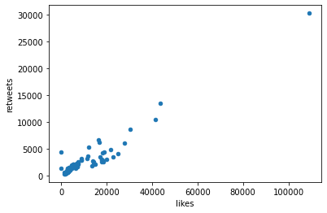

```python
twitter_cleaned_2.plot(x='likes',y='retweets',kind='scatter')
```

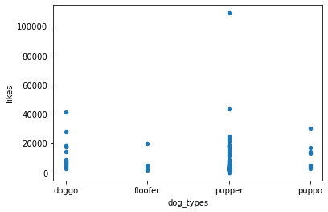

```python
#the relation between likes and dog_type
twitter_cleaned_2.plot(x='dog_types',y='likes',kind='scatter')
```

```python
#the count of each dog type
twitter_cleaned_2['dog_types'].value_counts()
```

```
pupper     148
doggo       53
puppo       20
floofer      5
Name: dog_types, dtype: int64
```

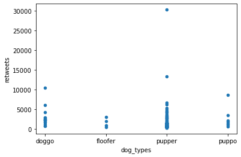

```python
#the relation between dog_type and retweet
twitter_cleaned_2.plot(x='dog_types',y='retweets',kind='scatter')
```

# Insight

> The least liked and retweeted dog type is floofer and the most liked and retweeted dog_type is pupper

[figure not shown]

```python
# the relation between rating and the likes
merged_df.plot(x='rating_numerator',y='likes',kind='scatter')
```

# Insight

> the tweets with high rating numerator are liked more

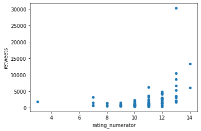

```python
#relation between retweets and rating
twitter_cleaned_2.plot(x='rating_numerator',y='retweets',kind='scatter')
```

# Insight

> tweets with a high rating numerator also have more retweets

```python
twitter_cleaned_2.head(5)
```

|  | tweet_id | timestamp | source | text | rating_numerator | rating_denominator | name | variable | dog_types | jpg_url | ... | p1_confidence | p1_dog | p2 | p2_confidence | p2_dog | p3 | p3_confidence | p3_dog | likes | retweets |
| --- | --- | --- | --- | --- | --- | --- | --- | --- | --- | --- | --- | --- | --- | --- | --- | --- | --- | --- | --- | --- | --- |
| 0 | 890240255349198849 | 2017-07-26 15:59:51+00:00 | <a href="http://twitter.com/download/iphone" r... | This is Cassie. She is a college pup. Studying... | 14 | 10 | Cassie | doggo | doggo | https://pbs.twimg.com/media/DFrEyVuW0AAO3t9.jpg | ... | 0.511319 | True | Cardigan | 0.451038 | True | Chihuahua | 0.029248 | True | 27984.0 | 6107.0 |
| 1 | 884162670584377345 | 2017-07-09 21:29:42+00:00 | <a href="http://twitter.com/download/iphone" r... | Meet Yogi. He doesn't have any important dog m... | 12 | 10 | Yogi | doggo | doggo | https://pbs.twimg.com/media/DEUtQbzW0AUTv_o.jpg | ... | 0.707046 | True | Malinois | 0.199396 | True | Norwegian Elkhound | 0.049148 | True | 17960.0 | 2508.0 |
| 2 | 871515927908634625 | 2017-06-04 23:56:03+00:00 | <a href="http://twitter.com/download/iphone" r... | This is Napolean. He's a Raggedy East Nicaragu... | 12 | 10 | Napolean | doggo | doggo | https://pbs.twimg.com/media/DBg_HT9WAAEeIMM.jpg | ... | 0.974781 | True | Briard | 0.020041 | True | Swab | 0.003228 | False | 17909.0 | 2945.0 |
| 3 | 869596645499047938 | 2017-05-30 16:49:31+00:00 | <a href="http://twitter.com/download/iphone" r... | This is Scout. He just graduated. Officially a... | 12 | 10 | Scout | doggo | doggo | https://pbs.twimg.com/media/DBFtiYqWAAAsjj1.jpg | ... | 0.955156 | True | Toy Terrier | 0.008054 | True | Muzzle | 0.006296 | False | 14231.0 | 2642.0 |
| 4 | 851953902622658560 | 2017-04-12 00:23:33+00:00 | <a href="http://twitter.com/download/iphone" r... | RT @dog_rates: This is Astrid. She's a guide d... | 13 | 10 | Astrid | doggo | doggo | https://pbs.twimg.com/media/C4KHj-nWQAA3poV.jpg | ... | 0.757547 | True | American Staffordshire Terrier | 0.149950 | True | Chesapeake Bay Retriever | 0.047523 | True | NaN | NaN |

5 rows × 22 columns

# INSIGHTS

> 3.There is a positive relation between rating numeator and likes

# VISUALIZATION

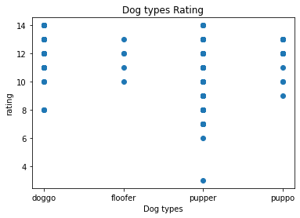

```python
import matplotlib.pyplot as plt
x= twitter_cleaned_2['dog_types']; y =twitter_cleaned_2['rating_numerator']
plt.scatter(x,y)
plt.title("Dog types Rating")
plt.xlabel("Dog types")
plt.ylabel("rating")
plt.show()
```